# Predict online news popularity

Data Science 2 - Exam

Viktória Mészáros

11/04/2021

## Aim

In this project my aim is to predict the popularity of online news. For this I am using a data set containing 27 752 new articles and 60 different characteristics about them. I built several different models from different types. I created a penalized linear model, random forest models, gradient boosting machines and XGBoost models as well as a kmeans model and neural nets with the aim to maximize accuracy.

## Exploratory data analysis

The outcome variable of my analysis will be *is_popular* which is a binary variable 1 indicating a news article is popular and 0 indicating it is not. In my data most of the articles were not popular, and only 20% of them are cataegoriezes as popular. This is not a lot, and if real life data is similar to what I have 80% of the articles should end up being not popular so predicting they are not popular should lead to an 80% accuracy. But this is not the aim of analysis! It is important to note that the smaller amount/ smaller percentage on popular articles makes it harder to predict them accurately. 20% is not too low, so it does not make prediction impossible, only a little bit more difficult.

| is_popular | Number of companies | Percentage |
| --- | --- | --- |
| 0 | 22286 | 80% |
| 1 | 5466 | 20% |

Lets look at the distribution for all the variables. I decided not to do any transformations and leave the values as they are to keep all the information they contain. I only changed the outcome varibale’s data type to factor.

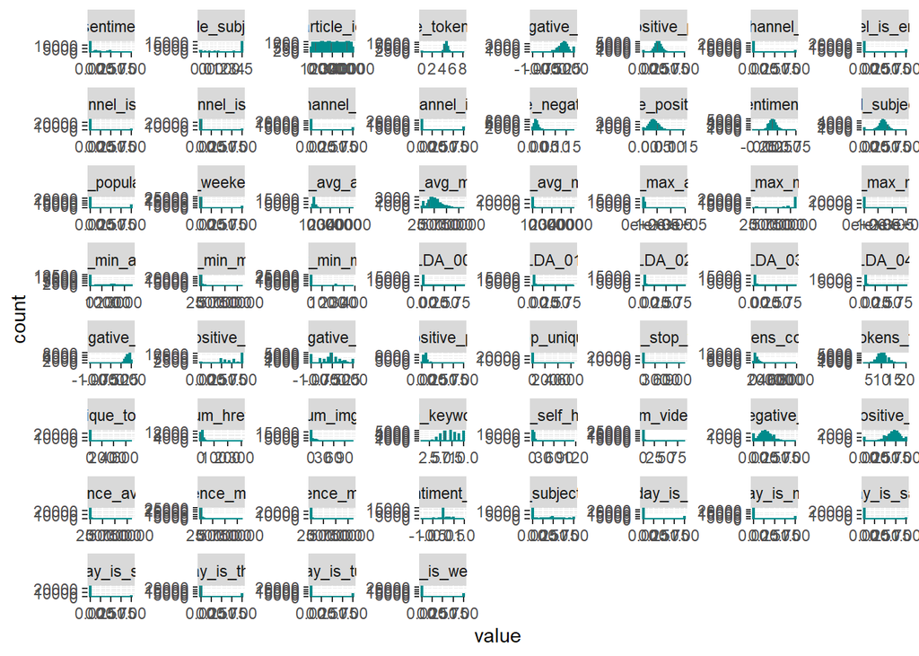

Looking at the correlations we already see some more important variables in prediction of popularity, and also see correlated variables. It is a good idea to built penalized linear models instead of simple linears to deal with this issue. (I tried out taking the log of the skewed variables with a long right tail, but it did not improve my models significantly so decided to keep them as they are)

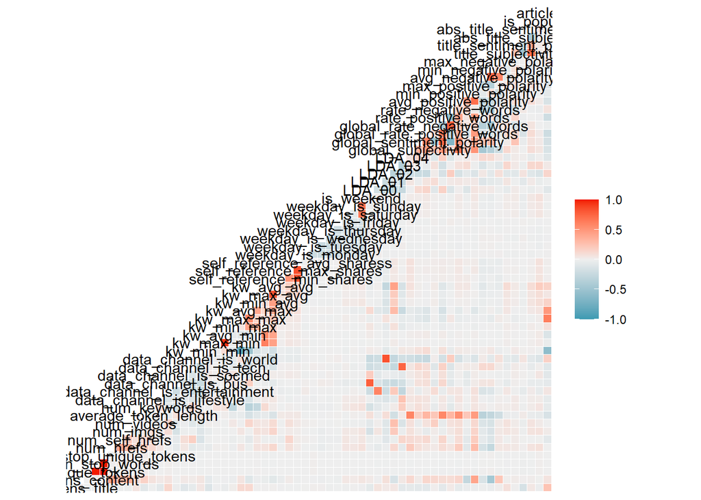

```r
ggcorr(df)
```

## Train, validation set

I divided my data to two sets. 80% of observations become part of the train set and I built all my model on this. The remaining 20% was the validation set I used to chose the best models. I t is important to evaluate the models on a validation set and chose the best based on this unknown, new data to avoid over fitting on the train set. All data sets were similar in terms of distribution of the outcome variable which is important. I used a 5 fold cross validation to find the best parameters during the tuning of my models.

```
## df$is_popular
##        n  missing distinct
##    27752        0        2
##
## Value      NotPopular    Popular
## Frequency       22286       5466
## Proportion      0.803      0.197
```

```
## data_train$is_popular
##        n  missing distinct
##    22202        0        2
##
## Value      NotPopular    Popular
## Frequency       17829       4373
## Proportion      0.803      0.197
```

```
## data_valid$is_popular
##        n  missing distinct
##     5550        0        2
##
## Value      NotPopular    Popular
## Frequency        4457       1093
## Proportion      0.803      0.197
```

## Linear models

I built 3 linear models. One really basic simple lm model. We already saw that some variables are correlated and there are a lot of them so to solve these issues I built an elastic net model to perform principled variable selection as well as to shrink coefficients. The third model was an elastic net including PCA. For the eleastic net and the elastic net with the PCA I used the same tuning grid where I looked at alpha values from 0 to 1 (by 0.1 steps) and tried out several lambda parameters as well. The best model was the eleastic net without PCA. For this the best tuning parameters were alpha = 1 and lambda = 0.0006158482.

|  | Validation AUC |
| --- | --- |
| Simple lm | 0.6839929 |
| Enet | 0.6844207 |
| Enet with PCA | 0.6669879 |

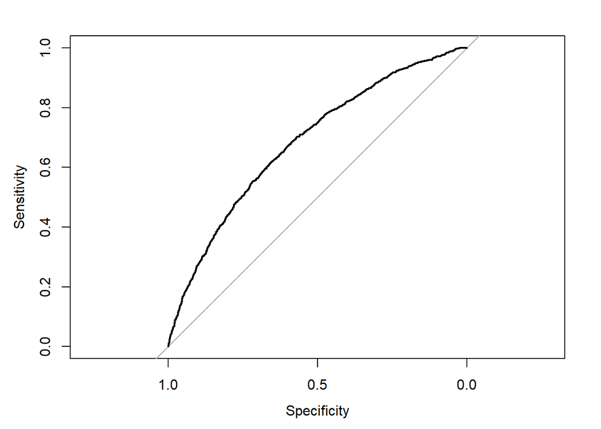

## Random forest models

|  | Validation AUC |
| --- | --- |
| Simple rf | 0.9816405 |
| Complex tuned rf | 0.9787248 |
| Auto tuned rf | 0.9845228 |

## Gradient boosting

|  | Train AUC |
| --- | --- |
| gbm_model | 0.7099197 |
| gbm_model_2 | 0.7160107 |
| xgb_model_2 | 0.7183614 |

|  | Validation AUC |
| --- | --- |
| Simple GBM | 0.7537389 |
| Complex tuned GBM | 0.7598757 |
| XGBoost | 0.7750006 |

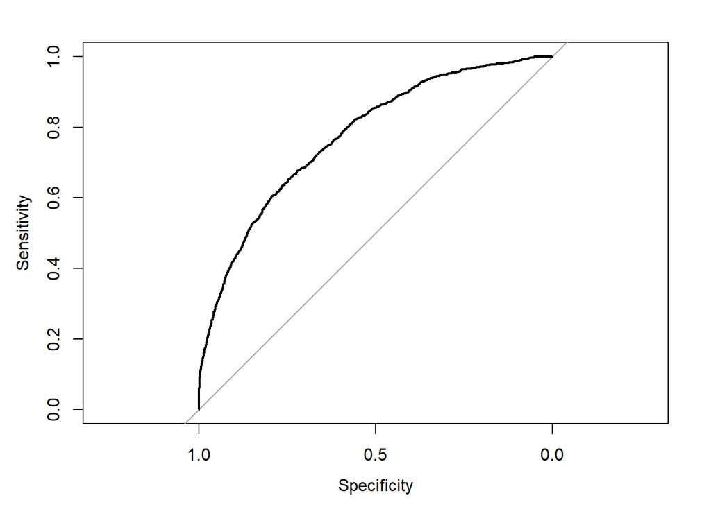

## Neural nets

Finally I built two neural net model, one basic and one with different starting points. I considered some different tuning opportunities here as well. You can check the codes for all the values I checked. The simple nnet model turned out to be better.

|  | Validation AUC |
| --- | --- |
| NNet model | 0.7059539 |
| AVNNet model | 0.7049874 |

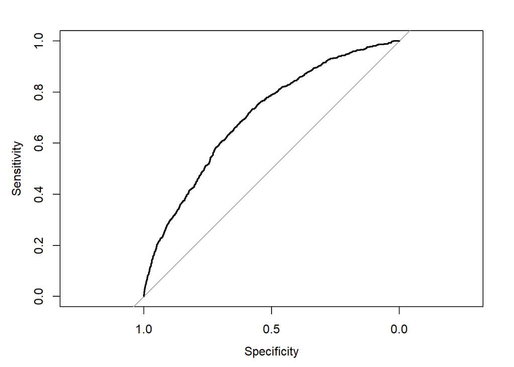

## Extra

There is a methos to summarize the findings of more models to a final summary model with stacking oif them. I would need to stack the models I uilt together and use tham together to predict the results. As I built the models using caret, but we only covered how to build stacked models using H2O, I built 4 baseline learners one glm, one random forest, one gbm and one deeplearning model in H2o and stacked these together. Unfortunately the performance of the model was lower than I expected as all the model tuning was lost that I done during other models.